# Multi-cue recall (v3.4 and v3.5)

## Participants

- N = 40

## Sanity and data-quality checks

### Probability of remembering first word

As a sanity check, we first ask if our memory strength index predicts participants choices about which image to recall. We operationalize memory strength as the within-participant Z-scored, mean-log 2AFC RT (that’s a mouthful!)

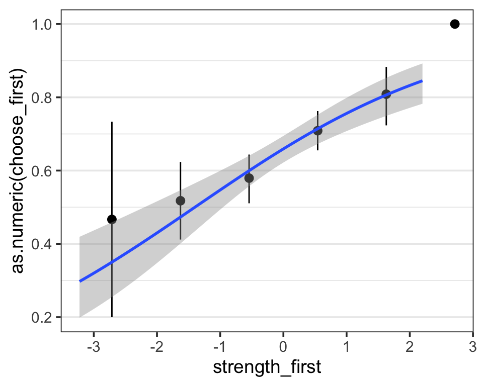

```r
multi %>% ggplot(aes(strength_first, as.numeric(choose_first))) +
    stat_summary_bin(fun.data=mean_cl_boot, bins=5) +
    geom_smooth(method = "glm", method.args = list(family = "binomial"), formula=y~x)
```

```r
lmer(choose_first ~ strength_first + (strength_first|wid), data=multi) %>% summ
```

| Fixed Effects | Fixed Effects Est. | Fixed Effects S.E. | Fixed Effects t val. | Fixed Effects d.f. | Fixed Effects p |
| --- | --- | --- | --- | --- | --- |
| (Intercept) | 0.651 | 0.030 | 21.670 | 37.923 | 0.000 |
| strength_first | 0.100 | 0.018 | 5.635 | 35.205 | 0.000 |

p values calculated using Satterthwaite d.f.

Note: unless otherwise stated, all regression tables are maximal linear mixed effects models (i.e. random slopes and intercepts). Plotted regression lines are plain old OLS.

We can also look at the difference between first and second, and how each strength contributed independently.

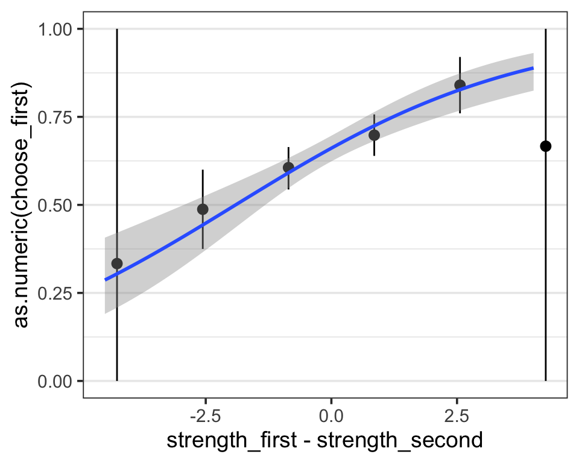

```r
multi %>% ggplot(aes(strength_first - strength_second, as.numeric(choose_first))) +
    stat_summary_bin(fun.data=mean_cl_boot, bins=5) +
    geom_smooth(method = "glm", method.args = list(family = "binomial"), formula=y~x)
```

```r
lmer(choose_first ~ relative_strength + (relative_strength|wid), data=multi) %>% summ
```

| Fixed Effects | Fixed Effects Est. | Fixed Effects S.E. | Fixed Effects t val. | Fixed Effects d.f. | Fixed Effects p |
| --- | --- | --- | --- | --- | --- |
| (Intercept) | 0.654 | 0.030 | 21.718 | 37.785 | 0.000 |
| relative_strength | 0.072 | 0.014 | 5.016 | 36.796 | 0.000 |

p values calculated using Satterthwaite d.f.

```r
lmer(choose_first ~ strength_first + strength_second + (strength_first + strength_second |wid), data=multi) %>% summ
```

| Fixed Effects | Fixed Effects Est. | Fixed Effects S.E. | Fixed Effects t val. | Fixed Effects d.f. | Fixed Effects p |
| --- | --- | --- | --- | --- | --- |
| (Intercept) | 0.654 | 0.030 | 21.778 | 37.776 | 0.000 |
| strength_first | 0.098 | 0.018 | 5.497 | 57.361 | 0.000 |
| strength_second | -0.047 | 0.019 | -2.457 | 37.732 | 0.019 |

p values calculated using Satterthwaite d.f.

### Number of presentations

Many trials have one presentation. The zero-presentation trials are mostly from two uncooperative (or confused) participants. Importantly we get a decent proportion of trials where both items are seen.

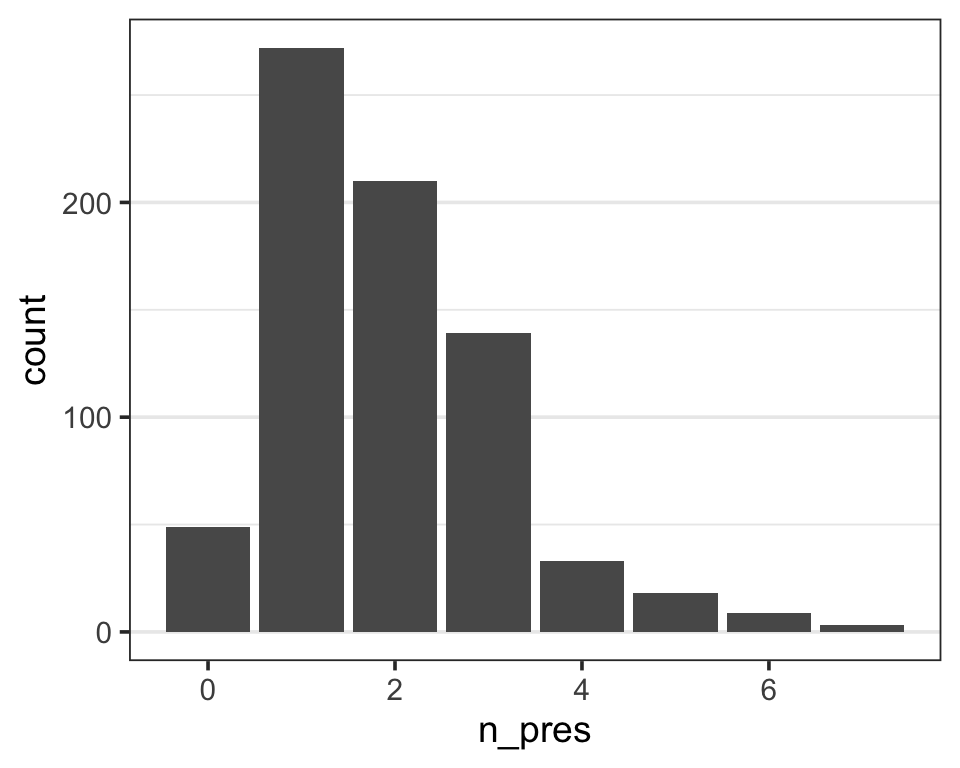

```r
multi %>% filter(n_pres <= 7) %>% ggplot(aes(n_pres)) +
    geom_bar()
```

Both cues are seen (n_pres ≥ 2) on 58% of trials.

**Conclusion:** We have a reliable measurement of memory strength (it predicts which target people remember) and we get enough switching to analyze that behavior.

Now let’s look for evidence of rational memory search.

## Proportion presentation time

The simplest test of rational memory: do people spend more time looking at the cue that they have a stronger memory of? This plot only considers trials where both cues are seen.

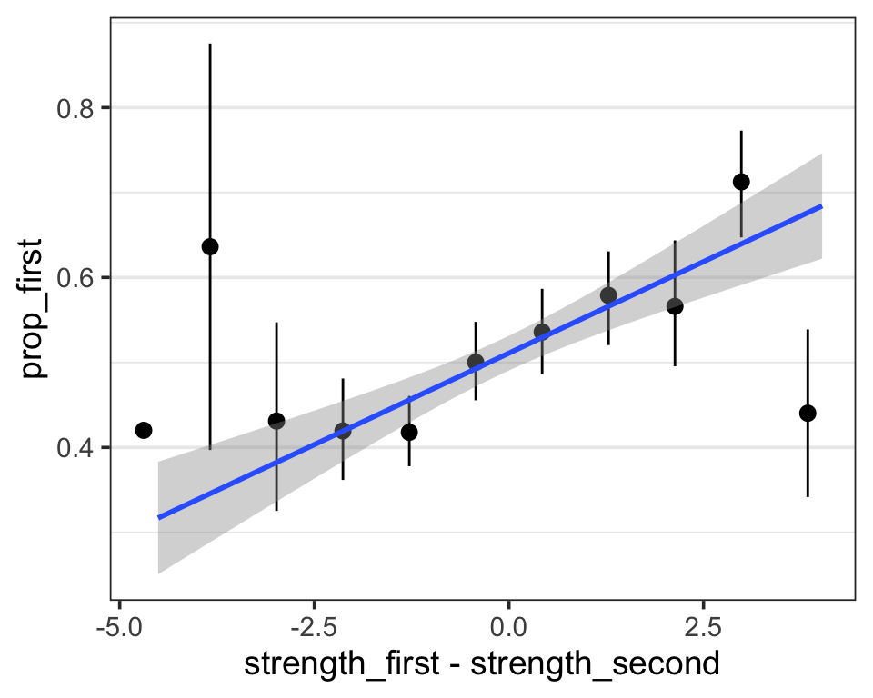

```r
X = multi %>%
    filter(n_pres >= 2) %>%
    mutate(prop_first = (total_first) / (total_first + total_second))

X %>% ggplot(aes(strength_first - strength_second, prop_first)) +
    stat_summary_bin(fun.data=mean_cl_boot, bins=10) +
    geom_smooth(method='lm')
```

```r
X %>% lmer(prop_first ~ relative_strength + (relative_strength|wid), data=.) %>% summ
```

| Fixed Effects | Fixed Effects Est. | Fixed Effects S.E. | Fixed Effects t val. | Fixed Effects d.f. | Fixed Effects p |
| --- | --- | --- | --- | --- | --- |
| (Intercept) | 0.509 | 0.015 | 34.646 | 33.413 | 0.000 |
| relative_strength | 0.041 | 0.009 | 4.768 | 29.598 | 0.000 |

p values calculated using Satterthwaite d.f.

```r
X %>% lmer(prop_first ~ strength_first + strength_second + (strength_first + strength_second|wid), data=.) %>% summ
```

| Fixed Effects | Fixed Effects Est. | Fixed Effects S.E. | Fixed Effects t val. | Fixed Effects d.f. | Fixed Effects p |
| --- | --- | --- | --- | --- | --- |
| (Intercept) | 0.511 | 0.010 | 49.205 | 433.315 | 0.000 |
| strength_first | 0.051 | 0.011 | 4.562 | 53.716 | 0.000 |
| strength_second | -0.034 | 0.011 | -2.953 | 43.097 | 0.005 |

p values calculated using Satterthwaite d.f.

**Conclusion:** It seems like people are spending more time on the one they have a stronger memory for. However, it should be noted that this effect can also emerge in a random switching model (although not nearly this strongly in the parameters I’ve looked at).

## First presentation duration

As we saw in my paper on fixations in simple choice, total presentation time can be a slightly tricky measure becuase recall cuts off the final fixation/presentation. The duration of the first presentation is potentially a more reliable cue.

Consider only the trials with more than one presentation. Do participants switch away from the first image more quickly when they have a worse memory of it?

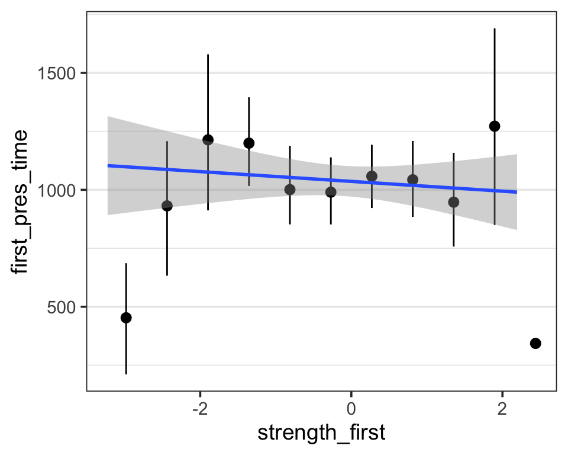

```r
X = multi %>%
    filter(n_pres > 1)

X %>% ggplot(aes(strength_first, first_pres_time)) +
    stat_summary_bin(fun.data=mean_cl_boot, bins=10) +
    geom_smooth(method='lm')
```

```r
X %>% lmer(first_pres_time ~ strength_first + (strength_first|wid), data=.) %>% summ
```

| Fixed Effects | Fixed Effects Est. | Fixed Effects S.E. | Fixed Effects t val. | Fixed Effects d.f. | Fixed Effects p |
| --- | --- | --- | --- | --- | --- |
| (Intercept) | 1383.844 | 156.890 | 8.820 | 25.946 | 0.000 |
| strength_first | 86.743 | 39.313 | 2.206 | 11.258 | 0.049 |

p values calculated using Satterthwaite d.f.

Very odd. The plotted fixed effect is non-significant (and slightly negative) while the mixed effects model gives a (barely) significant positive effect. Not sure what to make of this, but it suggests that some participants may be more rational than others. This could be a direction to explore more.

### Least memorable

It looks like there might be something going on with the least memorable cues. Looking only at trials where the strength of the first item is more than 1 SD below the mean, we do see an effect. But of course this is a prototypical case of p-hacking.

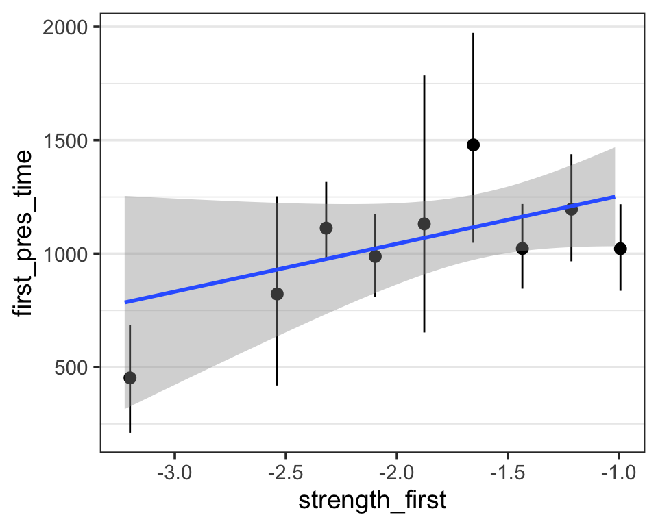

```r
X = multi %>%
    filter(n_pres > 1) %>%
    filter(strength_first < -1)

X %>% ggplot(aes(strength_first, first_pres_time)) +
    stat_summary_bin(fun.data=mean_cl_boot, bins=10) +
    geom_smooth(method='lm')
```

```r
X %>%
    lmer(first_pres_time ~ strength_first + (strength_first|wid), data=.) %>% summ
```

| Fixed Effects | Fixed Effects Est. | Fixed Effects S.E. | Fixed Effects t val. | Fixed Effects d.f. | Fixed Effects p |
| --- | --- | --- | --- | --- | --- |
| (Intercept) | 1673.073 | 239.607 | 6.983 | 10.156 | 0.000 |
| strength_first | 280.683 | 101.561 | 2.764 | 32.800 | 0.009 |

p values calculated using Satterthwaite d.f.

```r
    # lmer(first_pres_time ~ strength_first + (strength_first|wid), data=.) %>% summ
```

**Conclusion:** There is weak evidence that some people are able to recognize cues with low memory strength and switch away from them faster, especially for cues with very low strength. There appears to be substantial individual variation that could be worth further exploration.

## Second presentation duration

We can do a similar analysis for the second presentation duration. In this case, however, the duration may depend on the strength of both the first and second cues.

### Second-seen strength

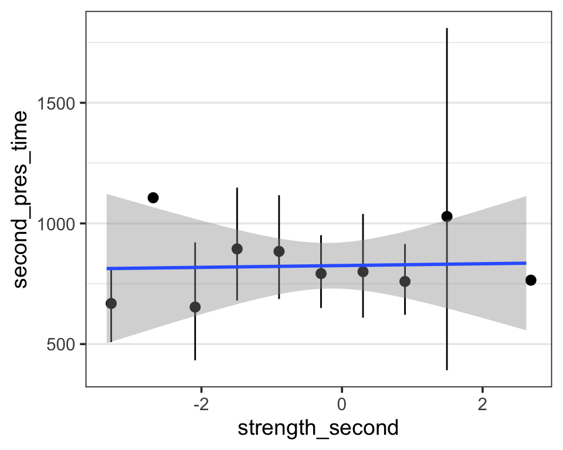

```r
X = multi %>%
    filter(n_pres > 2) %>%
    mutate(second_pres_time = map_dbl(presentation_times, 2, .default=NaN))

X %>% ggplot(aes(strength_second, second_pres_time)) +
    stat_summary_bin(fun.data=mean_cl_boot, bins=10) +
    geom_smooth(method='lm')
```

```r
X %>% lmer(second_pres_time ~ strength_second + (1|wid), data=.) %>% summ
```

| Fixed Effects | Fixed Effects Est. | Fixed Effects S.E. | Fixed Effects t val. | Fixed Effects d.f. | Fixed Effects p |
| --- | --- | --- | --- | --- | --- |
| (Intercept) | 1008.728 | 111.284 | 9.064 | 27.144 | 0.000 |
| strength_second | 15.943 | 37.989 | 0.420 | 204.296 | 0.675 |

p values calculated using Satterthwaite d.f.

### First-seen strength

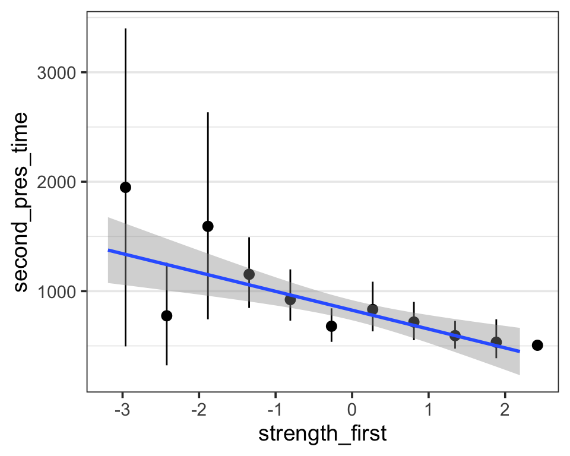

```r
X %>% ggplot(aes(strength_first, second_pres_time)) +
    stat_summary_bin(fun.data=mean_cl_boot, bins=10) +
    geom_smooth(method='lm')
```

```r
X %>% lmer(second_pres_time ~ strength_first + (strength_first|wid), data=.) %>% summ
```

| Fixed Effects | Fixed Effects Est. | Fixed Effects S.E. | Fixed Effects t val. | Fixed Effects d.f. | Fixed Effects p |
| --- | --- | --- | --- | --- | --- |
| (Intercept) | 1016.550 | 112.422 | 9.042 | 23.809 | 0.000 |
| strength_first | -103.104 | 58.211 | -1.771 | 17.685 | 0.094 |

p values calculated using Satterthwaite d.f.

### Relative strength (first - second)

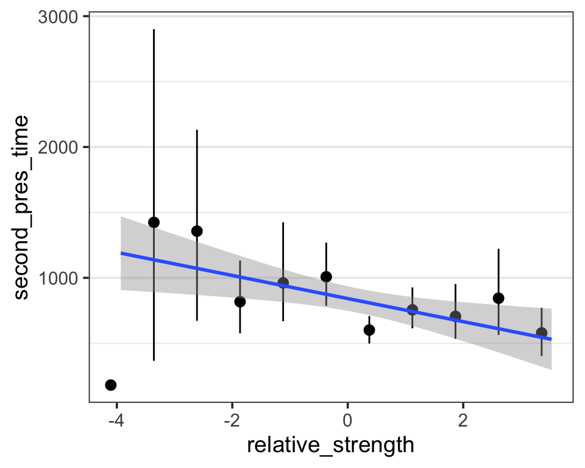

```r
X %>% ggplot(aes(relative_strength, second_pres_time)) +
    stat_summary_bin(fun.data=mean_cl_boot, bins=10) +
    geom_smooth(method='lm')
```

```r
X %>% lmer(second_pres_time ~ relative_strength + (relative_strength|wid), data=.) %>% summ
```

| Fixed Effects | Fixed Effects Est. | Fixed Effects S.E. | Fixed Effects t val. | Fixed Effects d.f. | Fixed Effects p |
| --- | --- | --- | --- | --- | --- |
| (Intercept) | 1006.790 | 110.517 | 9.110 | 26.735 | 0.000 |
| relative_strength | -81.540 | 41.476 | -1.966 | 23.984 | 0.061 |

p values calculated using Satterthwaite d.f.

We see no effect of the strength of the second-seen item on the duration of the second presentation. But we see (in the plot) a strong effect of the first-seen strength. The relative strength is a stronger predictor indicating that the second strength is playing a role. In a cruel twist of fate, the random slopes kill all our effects this time. However, the second two effects (first and relative) survive random intercepts. So I suspect we will get a significant effect in a larger sample.

**Conclusion:** We see fairly compelling evidence of rationality in the decision to switch *back* to the first item. Oddly, this effect is strong in aggregate but insignificant in a mixed effects model, the opposite as the previous analysis.

## Discussion

Overall, this looks pretty good to me. Before gathering more data, I would like to (1) talk through the paradigm to make sure we don’t have any reviewer traps and (2) think about additional predictions we might want to pre-register. Although what we have now might already be enough to make the first-order point, that people can use progress signals to direct their memory recall strategies.